# Monthly labour market stats update

Using styles derived from Edward Tufte

Paul Bivand

2016-03-28

# Introduction

This is a bit of a test of using the JSON downloads from ONS as well as the Tufte styles.

Notes:

1. The ONS JSON downloads are rounded to the published figures. This means that any calculated figures *may* not be the same as published ONS changes, which are based on unrounded figures then rounded after calculation. The ONS Excel downloads are unrounded (and also in absolute numbers not thousands);
2. My default image is to show time trends over the last two years, with y axis limits defaulting to a margin around the maximum and minimum occurring within that timeframe. The reason for this is that I’m interested in trying to find out whether there is any recent change in trend. If the minimum was set to zero then these changes would not be visible.

Let’s download the figures from ONS for unemployment and the unemployment rate, and then create ggplot2 sparklines and a dygraphs interactive with a default 2-year range set. The dygraphs can display the whole range, but on opening should show just the last 2 years.

That downloaded all the data with a 1971 base year. The first data is for January to March 1971, and is shown as February here. Data before March-May 1992 is modelled from annual Labour Force Surveys and prior datasets such as the Claimant Count and Employee Jobs estimates. The pre-1992 estimates are niticeably smoother than the post-1992 figures that are based on the continuously running Labour Force Survey.

For the sparklines in ggplot2 I need to select the relevant series and transform them into a data.frame.

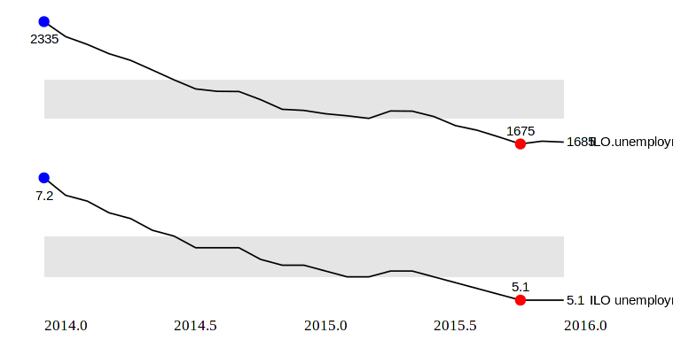

Unemployment (ILO definition) and the Unemployment rate

First thoughts: The sparklines are OK but the series titles run off the chart and the date numbering is funky. The unemployment numbers are thousands which can be multiplied by 1000 to give actuals, but getting big.marks as commas might be hard.

Meanwhile, should add some text.

## Chart 1: UK unemployment (ILO)

Unemployment is 1,685,000, *down* -5,000 from last month’s published figure (quarterly headline *down* -28,000) and the *unemployment rate* is 5.1%, *down* 0 percentage points on last month and *down* -0.1 percentage points on last quarter.

Now for a go at the Dygraphs. These will need to be done individually.

[interactive chart not shown]

That works, though some additional formatting may be needed later on such as colours. It looks as though they may work in the margin, too. They don’t.

The latest unemployment figure is 1,685,000. It has fallen by -5,000 from the figure published last month. The unemployment rate stayed at 5.1%.

[interactive chart not shown]

## Chart 15 Employment (number)

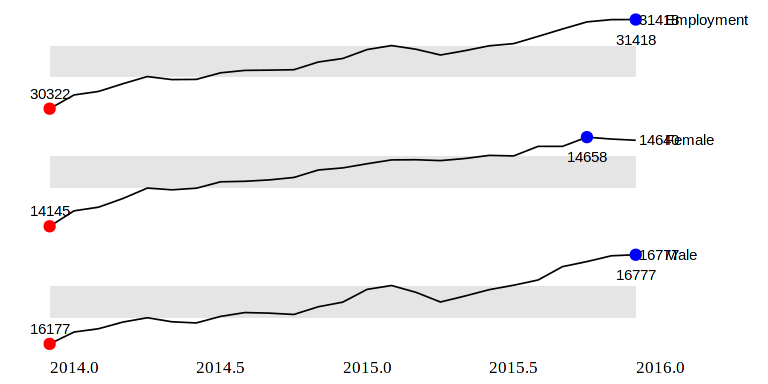

Employment, Female employment and Male employment

Employment is 31,418,000, *up* 1,000 from last month’s published figure (quarterly headline *up* 116,000).

Male employment is 16,777,000, *up* 7,000 from last month’s published figure (quarterly headline *up* 80,000).

## Chart 16 Employment rate

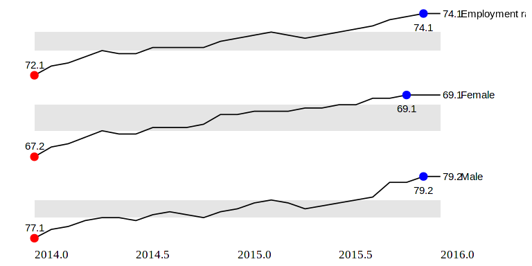

Employment rates, All, Female and Male

The *employment rate* is 74.1%, (*up* 0 percentage points on last month’s published figure and *up* 0.199999999999989 percentage points in the preferred quarterly measure).

The female employment rate is 69.1%, *up* 0 from last month’s published figure (quarterly headline *up* 0.0999999999999943).

Male employment is 79.2, *up* 0 from last month’s published figure (quarterly headline *up* 0.200000000000003).